# Covid-19 final project

Xiaowen JI

May 15, 2020

```r
#install.packages("dplyr")
#install.packages("zoo")
#install.packages("astsa")
#install.packages("ggplot2")
#install.packages("xts")
library(xts)
library(zoo)
library(dplyr)
library(astsa)
library(ggplot2)
library(lubridate)
```

# Extracting community mobility,daily new cases,total test for California

```r
setwd("D:/Clinical_decision_support/covid-19 Project")
GlMobility <- read.csv('Global_Mobility_Report.csv')

CA_Mobi <- GlMobility %>% slice(104794:104868)

CA_Mobi <- rename(CA_Mobi,retail=retail_and_recreation_percent_change_from_baseline,
                  grocery=grocery_and_pharmacy_percent_change_from_baseline,
                  parks=parks_percent_change_from_baseline,
                  transit=transit_stations_percent_change_from_baseline,
                  workplace=workplaces_percent_change_from_baseline,
                  residence=residential_percent_change_from_baseline)

anyNA(CA_Mobi)
```

```
## [1] FALSE
```

```r
setwd("D:/Clinical_decision_support/covid-19 Project")
California <- read.csv("California.csv")
CA_newconfirm <- select (California,date,new_confirmed)

anyNA(CA_newconfirm)
```

```
## [1] FALSE
```

```r
setwd("D:/Clinical_decision_support/covid-19 Project")
CA_total_test <- read.csv("CA_total_test.csv")
anyNA(CA_total_test)
```

```
## [1] FALSE
```

# Creating two time-series data using zoo package

# Only one kind of mobility can be produced once a time;taking mobility trend toward residence as an example

```r
tsCA_Mobi <- zoo(#CA_Mobi$retail,
                 #CA_Mobi$grocery,
                 #CA_Mobi$parks,
                 #CA_Mobi$transit,
                 #CA_Mobi$workplace,
                 CA_Mobi$residence,
                 seq(from = as.Date("2020-02-16"),
                 to = as.Date("2020-04-30"), by = 1))


summary(tsCA_Mobi)
```

```
##      Index              tsCA_Mobi
##  Min.   :2020-02-16   Min.   :-1.00
##  1st Qu.:2020-03-05   1st Qu.: 0.50
##  Median :2020-03-24   Median :16.00
##  Mean   :2020-03-24   Mean   :12.59
##  3rd Qu.:2020-04-11   3rd Qu.:22.00
##  Max.   :2020-04-30   Max.   :26.00
```

```r
tsCAnew <- zoo(CA_newconfirm$new_confirmed, seq(from = as.Date("2020-02-21"),
               to = as.Date("2020-05-12"), by = 1))


summary(tsCAnew)
```

```
##      Index               tsCAnew
##  Min.   :2020-02-21   Min.   :   0.0
##  1st Qu.:2020-03-12   1st Qu.:  43.0
##  Median :2020-04-01   Median : 920.5
##  Mean   :2020-04-01   Mean   : 865.5
##  3rd Qu.:2020-04-21   3rd Qu.:1380.8
##  Max.   :2020-05-12   Max.   :2779.0
```

```r
tsCAtotaltest <- zoo(CA_total_test$Total_test, seq(from = as.Date("2020-03-04"), as.Date("2020-05-09"), by = 1))

summary(tsCAtotaltest)
```

```
##      Index            tsCAtotaltest
##  Min.   :2020-03-04   Min.   :   515
##  1st Qu.:2020-03-20   1st Qu.: 12008
##  Median :2020-04-06   Median :117431
##  Mean   :2020-04-06   Mean   :235650
##  3rd Qu.:2020-04-22   3rd Qu.:473712
##  Max.   :2020-05-09   Max.   :912570
```

# standalization-plot-on zoo objects

```r
nortsCA_Mobi <- scale(tsCA_Mobi)
nortsCAnew <- scale(tsCAnew)
norCAtotaltest <- scale(tsCAtotaltest)
```

# Plotting trends between mobility_residence and CA_daily new cases in ggplot

# Comparing trends before and after “stay-at-home” order (2020-03-19 shown in dashline) in CA

# Before the order(from early March),Californians were already increasing their morbility toward residence, meaning practing “stay -at-home” themselves.After the order, the mobility continue to increase, but to a lesser degree. It seems after the order, moblility fluctuate along with daily new cases

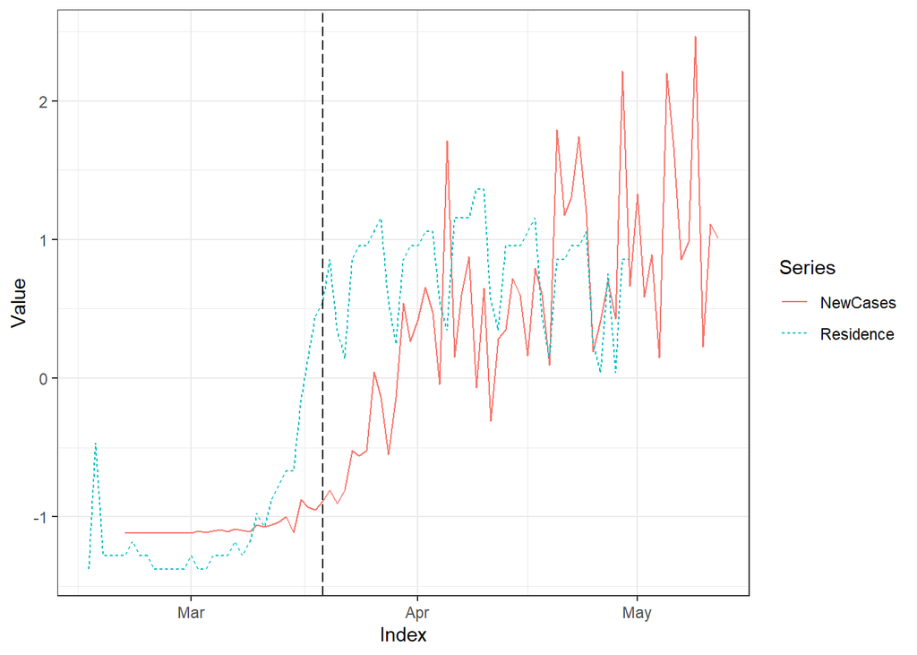

```r
CAdata <-cbind(nortsCA_Mobi,nortsCAnew)
forZoo_CA1 <- fortify.zoo(CAdata,names = c("Index","Series","Value"),melt = TRUE)

s <- tibble(crazyfactor = ymd(c(forZoo_CA1$Index)), value=c(1:174)) %>%
mutate(crazyfactor = as.factor(crazyfactor))
forZoo_CA1 <- forZoo_CA1%>%
  mutate(Series = as.character(Series)) %>%
  mutate(Series = replace(Series, Series == 'nortsCA_Mobi', 'Residence'))%>%
  mutate(Series = replace(Series, Series == 'nortsCAnew', 'NewCases'))
p1<-ggplot(forZoo_CA1, aes(x = Index, y = Value, Group = Series)) +
    geom_line(aes(color = Series, linetype = Series)) +
    geom_vline(aes(xintercept = Index[which(levels(s$crazyfactor) == '2020-03-19')]), col =    "black",linetype = "longdash") +theme_bw()
plot(p1)
```

#Lagged correlation between mobility and new cases to decide which lead which. There is a linear correlations between lagged mobility and daily new cases (p3), telling that as mobility toward homeplace increase, new cases increase. This weird outcome might be due to lack of early test and potential, uncontrolled communicty spread in Feb. even Jan. 2020. Yet, people’s practice of “stayin -at-home” is also led by daily new cases. The positive correlation taper with longer lagged day of new cases (p4)

```r
p2 <-ccf (tsCA_Mobi,tsCAnew)
```

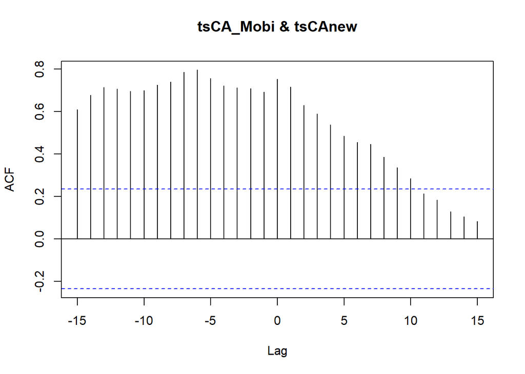

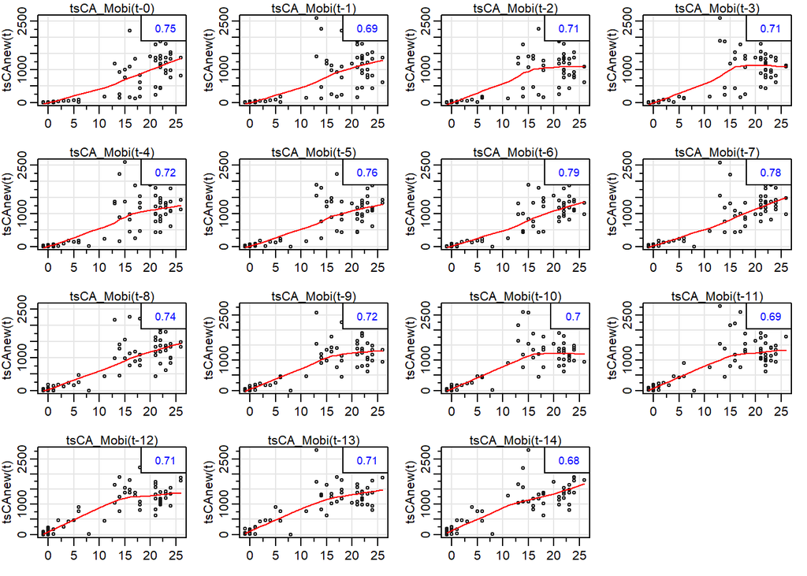

```r
p3 <-lag2.plot(tsCA_Mobi,tsCAnew,14)
```

```r
p4 <-ccf (tsCAnew,tsCA_Mobi)
```

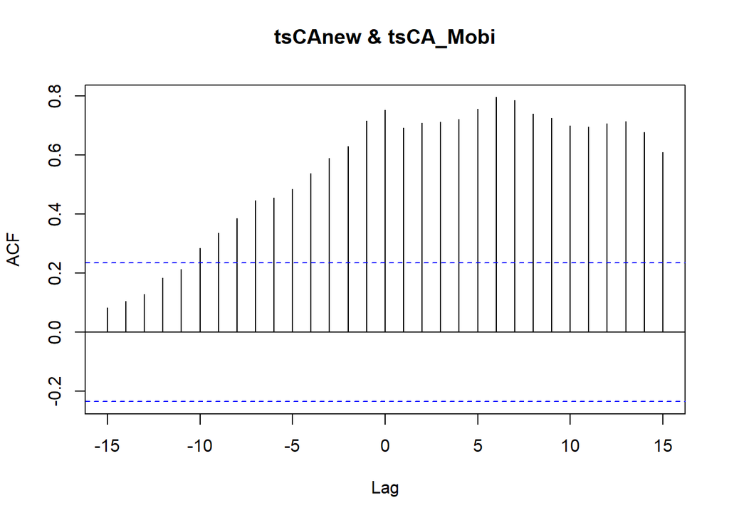

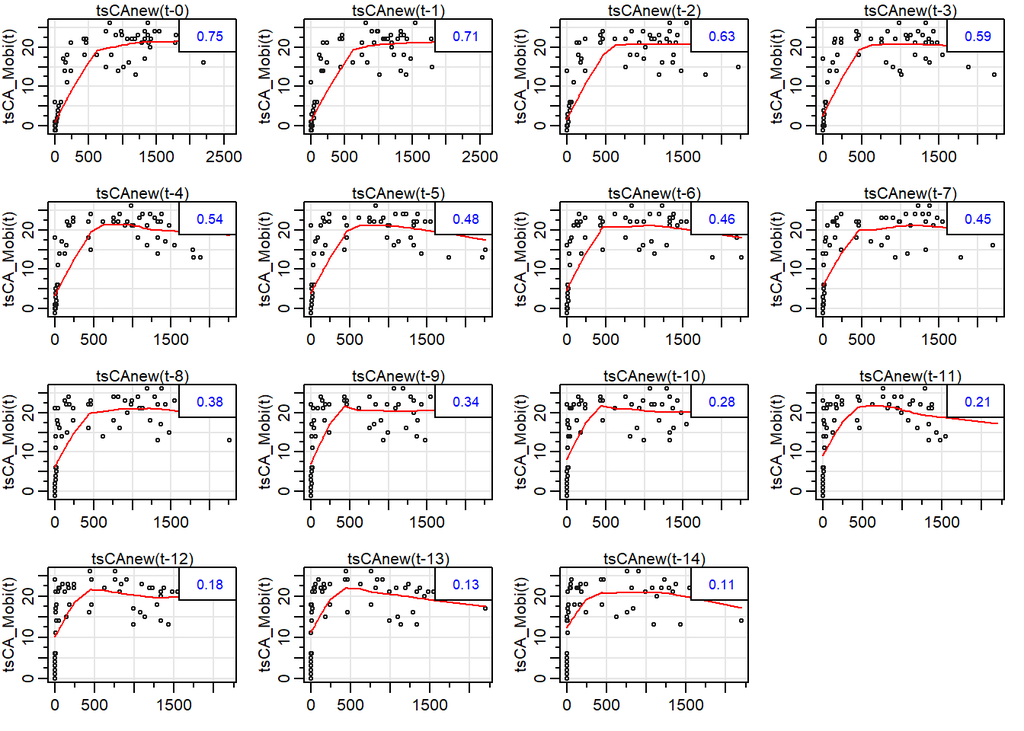

```r
p5 <-lag2.plot(tsCAnew,tsCA_Mobi,14)
```

# contrasting mobility and new cases with total_test data in plot # After “stay-at-home” order, much more tests conducted and new cases reported

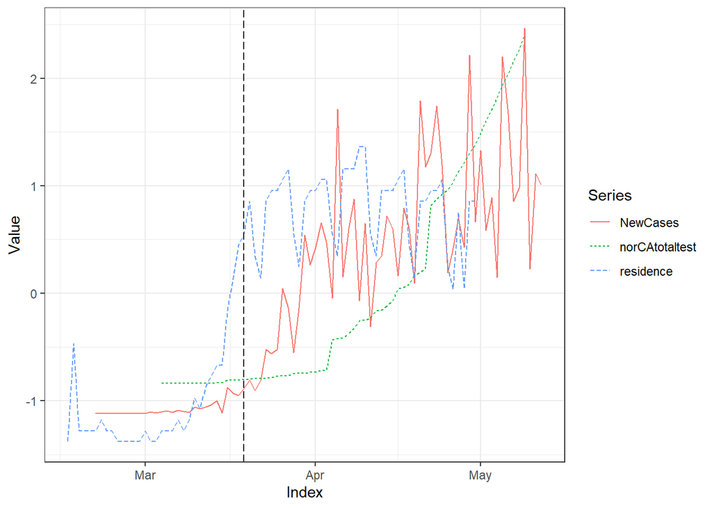

```r
CAdata1 <-cbind(nortsCA_Mobi,nortsCAnew,norCAtotaltest)
forZoo_CA3 <- fortify.zoo(CAdata1,names = c("Index","Series","Value"),melt = TRUE)
forZoo_CA3 <- forZoo_CA3%>%
  mutate(Series = as.character(Series)) %>%
  mutate(Series = replace(Series, Series == 'nortsCA_Mobi', 'residence'))%>%
  mutate(Series = replace(Series, Series == 'nortsCAnew', 'NewCases'))
ggplot(forZoo_CA3,aes(x = Index, y = Value, Group = Series))+
  geom_line(aes(color = Series, linetype = Series))+geom_vline(aes(xintercept = Index[which(levels(s$crazyfactor) == '2020-03-19')]), col = "black",linetype = "longdash")+theme_bw()
```